# MCC model predictions overview

Manuel Bohn

17 5 2018

## All model predictions and data

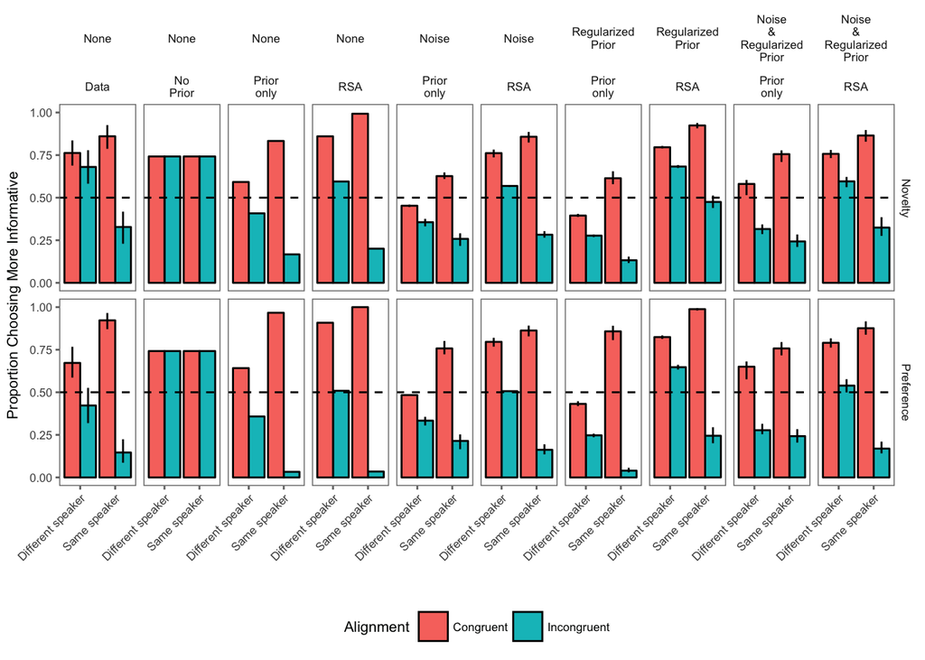

## Correlations between model predictions and data

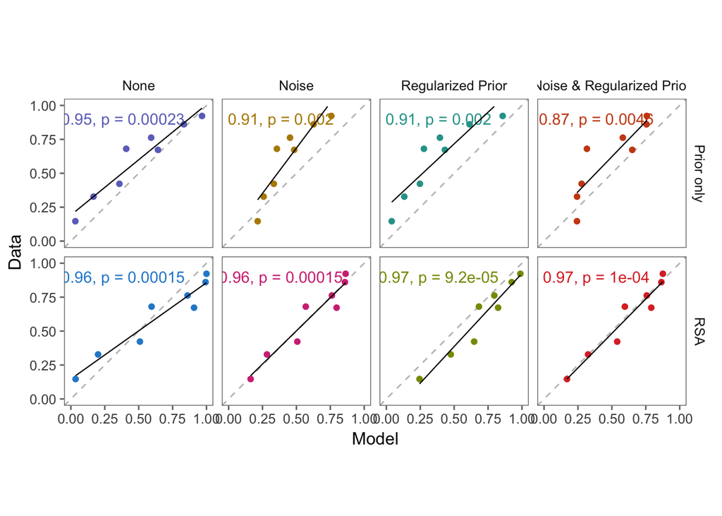

## Model descriptions

### Prior only Model with Noise

Mean noise parameter with 95% Credible Interval: 0.4 [0.31 : 0.49].

Model predictions: Very squashed (less extreme) compared to no adjustment predictions due to high noise parameter.

Qualitatively, predictions change compared to no adjustment predictions for different speaker - congruent (from above chance to chance).

4/8 predictions are qualitatively correct.

### RSA Model with Noise

Noise parameter: 0.28 [0.22 : 0.34]

Model predictions: Slightly squashed compared to no adjustment predictions.

Qualitatively predictions do not change.

8/8 predictions are qualitatively correct.

### Prior only Model with regularized Priors

Prior Exponent: 0.73 [0.63 : 0.83].

Model predictions: Again, very squashed (less extreme) compared to no adjustment predictions. Prior exponent parameter shows that priors are pulled towards uniform (and therefore to chance level).

Qualitatively, predictions change again for different speaker - congruent (from above chance to below chance). This is somehow strange as the uniform prior prediction in this case would be chance. Why is the prediction pushed below chance? This doesn’t really make sense.

4/8 predictions are qualitatively correct.

### RSA Model with regularized Priors

Prior Exponent: 0.42 [0.36 : 0.47]

Model predictions: Pulled strongly towards no prior model because priors are made more uniform.

Qualitatively, predictions change for same speaker incongruent in novelty (from below chance to chance) and for different speaker incongruent preference (at chance to above chance).

6/8 predictions are qualitatively correct.

### Prior only Model with Noise and regularized Priors

Noise parameter: 0.49 [0.41 : 0.57].

Prior Exponent: 3.18 [2.17 : 4.29].

Model predictions: Slightly squashed (less extreme). More noise compared to model with noise only adjustment. Prior exponent suggests that priors are made more extreme - probably due to high noise parameter.

No qualitative change.

6/8 predictions are qualitatively correct.

### RSA Model with Noise and regularized Priors

Mean noise parameter with 95% CrI: 0.25 [0.17 : 0.33].

Mean priorExponent with 95% CrI: 0.82 [0.62 : 1.03].

Model predictions: Slightly squashed (less extreme). A little less noisy compared to model with only noise adjustment. Prior adjustment is also less strongly towards uniform.

No qualitative change.

8/8 predictions are qualitatively correct.

## Comparing models

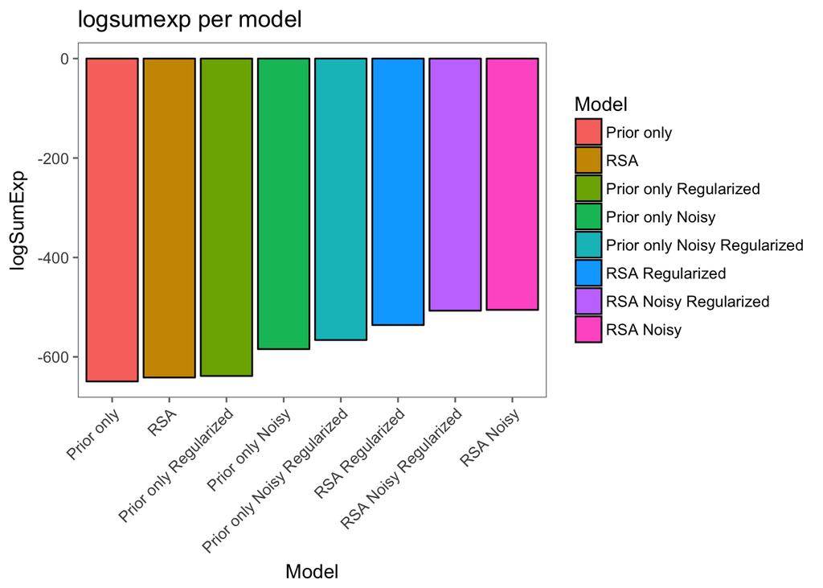

Log probabilities given the data for all models (except no prior model), computed via webppl.

| Model | logSumExp | max |
| --- | --- | --- |
| Prior only | -649.46 | -657.98 |
| Prior only Noisy | -584.41 | -593.78 |
| Prior only Noisy Regularized | -566.14 | -574.22 |
| Prior only Regularized | -638.48 | -646.36 |
| RSA | -641.46 | -649.98 |
| RSA Noisy | -505.52 | -514.57 |
| RSA Noisy Regularized | -507.08 | -513.28 |
| RSA Regularized | -536.03 | -543.41 |

Log probabilities given the data for non-parameterized models based on binomial distribution (full model = RSA).

| Model | log_p_data_given_model |
| --- | --- |
| Full model | -167.08 |
| No prior | -202.60 |
| Prior only | -72.12 |